# Supply Chains Under Stress

Stephen Weymouth

Dean’s Professor

2026-11-11

# In October 2021 the Maersk Emden waited sixteen days off Long Beach with a Mississippi firm’s Christmas toys (among other things) onboard.

## Your IB Voice

From Toyota to Long Beach

Goodman traces the shortages of 2021 back to a factory manager in postwar Japan. Explain how a practice that made firms more efficient also made them more exposed to a shock.

**8 minutes** · Individual · Notes permitted

## Competing explanations

Why did the world run out of everything in 2021?

Factories in China shut down, so there was less to ship.

People stuck at home bought more goods, and firms ordered extra to be safe.

Firms had kept so little stock that any delay became a shortage.

The companies that ran the ports gained from the delays and were slow to end them.

# Why did firms keep so little stock?

## Taiichi Ohno made only what the next step used

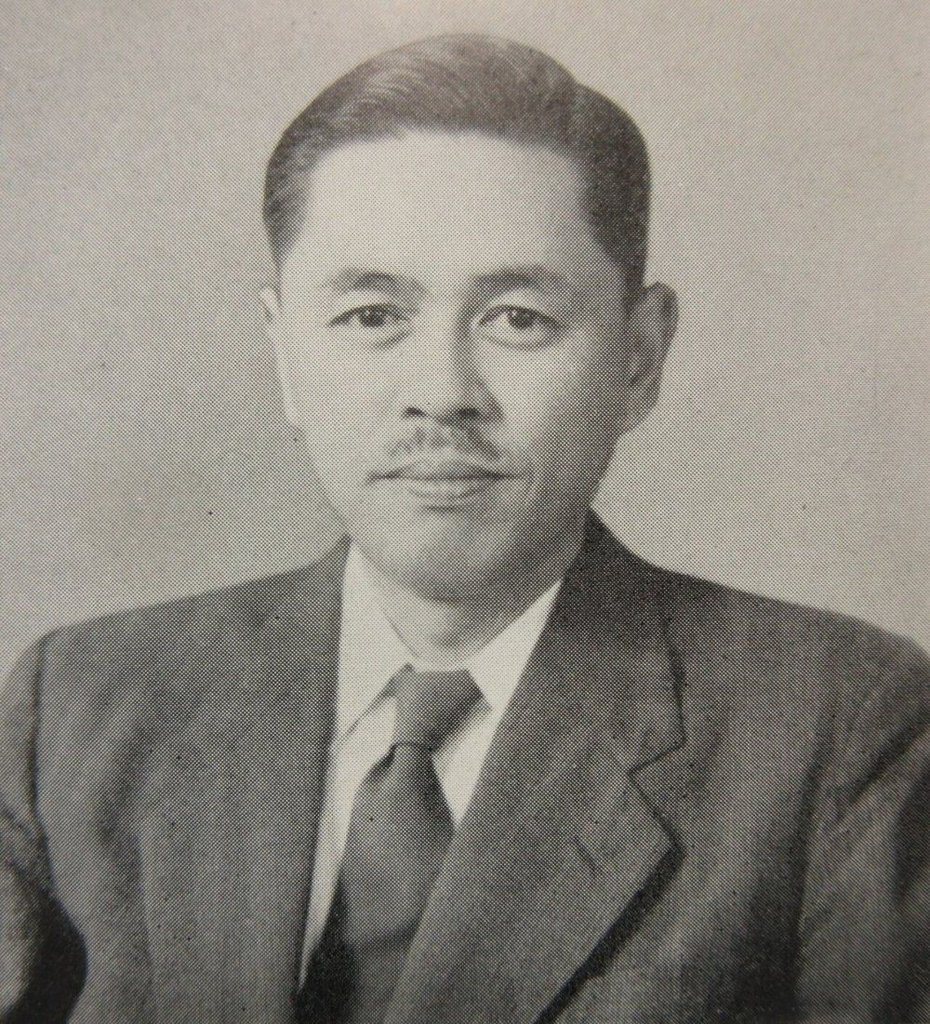

Toyota Motor Co. history committee, [Taiichi Ohno](https://commons.wikimedia.org/wiki/File:Ohno-Taiichi-1.jpg), 1958 · Wikimedia Commons, public domain

In 1950 Toyota built more trucks than it could sell and nearly went bankrupt.

Ohno copied the supermarket, which restocks only what customers take.

*Just in Time* means making and delivering each part only when the next step needs it.

## U.S. firms learned to hold less stock

By the late 1980s two-fifths of the largest U.S. manufacturers used some version of Just in Time.

Lean stock freed cash in normal years and left little to draw on in a bad one.

In 2021 firms ran their shelves down and could not refill them.

[figure not shown]

U.S. Census Bureau, [Total Business: Inventories to Sales Ratio](https://fred.stlouisfed.org/series/ISRATIO), via FRED, 2026: annual averages.

# Ohno wrote that his ancestors stored rice for disasters, and that business must give up such hoarding. Why did he believe Just in Time is a better idea?

## Just in Time fits steady demand and close suppliers

Toyota kept Just in Time for most parts but stockpiled chips after the 2011 earthquake, and built cars through most of the 2021 shortage.

The choice is made part by part, not for the whole firm.

*Just in case* means holding extra stock so that one failure does not stop production.

[figure not shown]

Original table, after the treatment of just-in-time inventory in standard international business texts and Goodman, 2024, ch. 3.

# Why could nobody clear the ports?

## Dozens of ships waited off Los Angeles

[figure not shown]

European Union, Copernicus Sentinel-2 imagery, October 10, 2021 · Wikimedia Commons, attribution

A *bottleneck* is the step with the least spare capacity.

## The jam moved inland

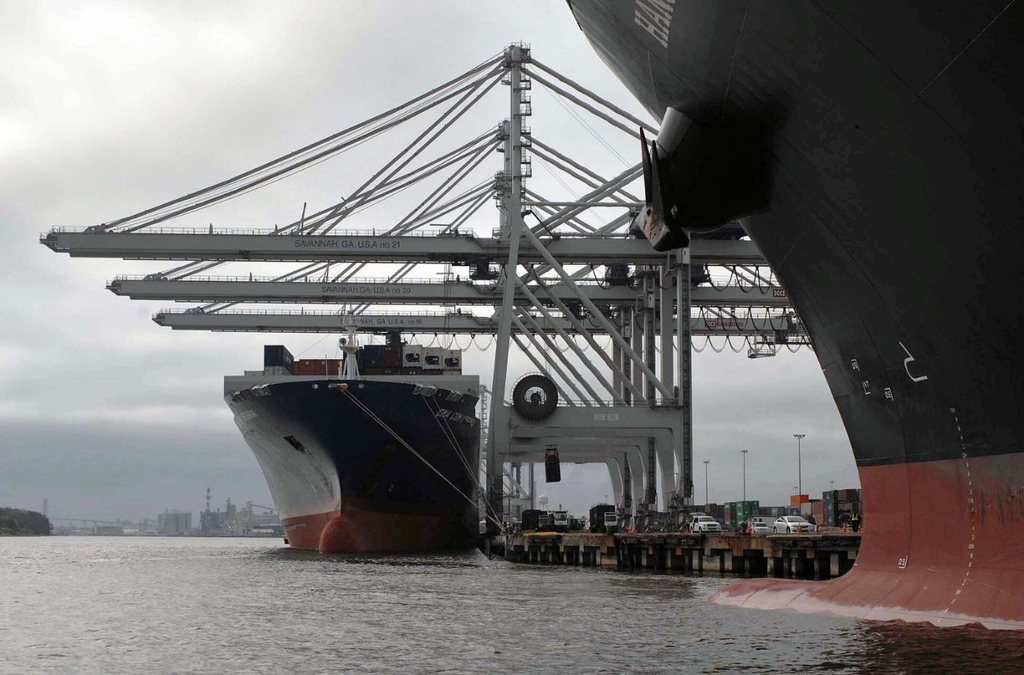

U.S. Army Corps of Engineers, Savannah Harbor, Garden City Ocean Terminal · Wikimedia Commons, public domain

Warehouses near the ports were full, so containers sat on trucks instead of being unloaded.

Without space, trucks could not collect the next boxes, and the yards filled up.

## During Covid, imports fluctuated more than spending

[figure not shown]

U.S. Bureau of Economic Analysis and Census Bureau, [spending on goods](https://fred.stlouisfed.org/series/DGDSRC1) and [goods imports](https://fred.stlouisfed.org/series/BOPGIMP), via FRED, 2026: monthly.

Stuck at home in 2020, shoppers bought more goods, and stores short of stock ordered extra from abroad.

Imports overshot spending in 2022, then fell well below it as stores cleared the surplus.

The *bullwhip effect* is the way small changes in what shoppers buy become large swings in orders up the chain.

## Maersk earned record profits during the jam

[figure not shown]

A.P. Moller-Maersk, annual results, 2020 to 2025: net profit.

Maersk ran one of the largest terminals in Los Angeles as well as the ships waiting outside.

Its CEO told investors it would not sell all its capacity unless demand was there.

A firm that controls a bottleneck can profit from it.

# Can a firm buy resilience?

## U.S. trade with China shrank by two-fifths

[figure not shown]

U.S. Census Bureau, goods trade with China, via [FRED](https://fred.stlouisfed.org/series/EXPCH), 2026: 2026 is January to September.

U.S. imports from China fell after the tariffs of 2018 and again after those of 2025.

China bought less from the United States too, so trade fell in both directions.

*Decoupling* is a deliberate cut in the trade and investment ties between two economies, usually for national security or political reasons.

## U.S. buyers shifted orders from China to Vietnam

In 2026 the United States is buying almost as much from Vietnam as from China.

China’s exports kept growing after 2018, but a smaller share went to the United States.

In 2019 an advisor urged Glo to spread its orders across factories in more than one country.

*Supply-chain resilience* is the ability to keep supplying when one source or route fails.

[figure not shown]

U.S. Census Bureau via [FRED](https://fred.stlouisfed.org/series/IMPCH); China’s customs data via [IMF](https://data.imf.org/en/datasets/IMF.STA:IMTS), 2026: 2026 is January to September for U.S. imports and January to July for China’s exports.

## The lowest factory price can lose on landed cost

[figure not shown]

Illustrative figures; method as in standard international business texts on global sourcing.

Here Mexico’s factory price is 30 percent higher than China’s, yet its landed cost is the lowest.

A change in tariffs or freight can change which country is cheapest.

*Total landed cost* is everything a buyer pays to get a product to its door, including shipping and tariffs, not only the factory price.

# “We’re not even breaking up with China. We’re just asking if we can also see other people at the same time.” Anna Barker, co-founder of Glo

## China does more than a quarter of world manufacturing

Hagan Walker, who runs Glo, asked for a display screen on Alibaba and had twenty quotes from factories within minutes.

Factories in Vietnam often import their parts from China.

Goodman calls this a *barrier to exit*: the scale that makes China cheap also makes leaving it hard.

[figure not shown]

World Bank, [World Development Indicators](https://data.worldbank.org/indicator/NV.IND.MANF.CD), 2026: manufacturing value added, 2025; United States from the [Bureau of Economic Analysis](https://fred.stlouisfed.org/series/VAMA); Japan is 2024.

## Diversifying

Goodman warns that moving production from China to several countries could leave firms more exposed to a shock. How can that be?

# What has closing Hormuz done to prices?

## U.S. diesel set a record in September

Diesel moves trucks, trains, ships, and farm machinery, so its price reaches almost every good.

The gap between diesel and crude widened, partly because Gulf refineries that supplied Europe stopped shipping.

A shock to one input raises the cost of moving everything else.

[figure not shown]

U.S. Energy Information Administration, [diesel](https://fred.stlouisfed.org/series/GASDESW) and [gasoline](https://fred.stlouisfed.org/series/GASREGW) retail prices and [Brent crude](https://fred.stlouisfed.org/series/DCOILBRENTEU), via FRED, 2026: weekly; crude converted at 42 gallons a barrel.

## Urea fell back, but phosphate kept rising

[figure not shown]

World Bank, [Commodity Price Data (Pink Sheet)](https://www.worldbank.org/en/research/commodity-markets), November 2026: urea, Middle East, and diammonium phosphate.

*Urea*, the most common nitrogen fertilizer, is made from natural gas. Its price fell back as China resumed exports.

Phosphate fertilizer needs sulfur, to make the acid that dissolves phosphate rock, and ammonia. Gulf supplies of both stayed scarce.

If farmers use less fertilizer, harvests shrink, and the shock reaches food a season later.

## Takeaways

How do shocks travel through supply chains?

Just in Time cut stock and spare capacity, so a delay soon became a shortage.

A chain moves only as fast as its narrowest step, and extra orders compounded the problem.

A firm that controls a bottleneck can profit from it and may be slow to clear it.

The cheapest source is the one with the lowest landed cost, and many alternatives to China still depend on China.

Gulf delays raise the cost of fuel and fertilizer for every supply chain that uses them.